# WALMART WEEKLY SALES FORECASTING

```python
import pandas as pd
import seaborn as sns
import matplotlib.pyplot as plt
import numpy as np

import warnings
warnings.filterwarnings("ignore")

plt.rcParams['font.sans-serif'] = "Arial"
plt.rcParams['font.family'] = "sans-serif"
background_color = '#fbfbfb'
color1 = '#C32D4B'
color2 = '#18846c'
color3 = '#6698FF'
```

# Data preparation (train data)

```python
data = pd.read_csv('walmart.csv')
df = data.copy()
df.head(1)
```

|  | Unnamed: 0 | Store | Date | IsHoliday | Dept | Weekly_Sales | Temperature | Fuel_Price | MarkDown1 | MarkDown2 | MarkDown3 | MarkDown4 | MarkDown5 | CPI | Unemployment | Type | Size |
| --- | --- | --- | --- | --- | --- | --- | --- | --- | --- | --- | --- | --- | --- | --- | --- | --- | --- |
| 0 | 1 | 1 | 2010-02-05 | False | 1.0 | 24924.5 | 42.31 | 2.572 | NaN | NaN | NaN | NaN | NaN | 211.096358 | 8.106 | A | 151315 |

```python
df.dtypes
```

```
Unnamed: 0        int64
Store             int64
Date             object
IsHoliday          bool
Dept            float64
Weekly_Sales    float64
Temperature     float64
Fuel_Price      float64
MarkDown1       float64
MarkDown2       float64
MarkDown3       float64
MarkDown4       float64
MarkDown5       float64
CPI             float64
Unemployment    float64
Type             object
Size              int64
dtype: object
```

```python
df=df.drop(columns=['Unnamed: 0'])
df.isnull().sum(axis=0)/len(df)*100
```

```
Store            0.000000
Date             0.000000
IsHoliday        0.000000
Dept             0.414575
Weekly_Sales     0.414575
Temperature      0.000000
Fuel_Price       0.000000
MarkDown1       63.991496
MarkDown2       73.417115
MarkDown3       67.245497
MarkDown4       67.763302
MarkDown5       63.813382
CPI              0.138192
Unemployment     0.138192
Type             0.000000
Size             0.000000
dtype: float64
```

```python
df = df[df.Weekly_Sales.notna()].sort_values(by=['Store','Dept','Date']).reset_index(drop=True)
df.shape
```

```
(421570, 16)
```

```python
df.head(2)
```

|  | Store | Date | IsHoliday | Dept | Weekly_Sales | Temperature | Fuel_Price | MarkDown1 | MarkDown2 | MarkDown3 | MarkDown4 | MarkDown5 | CPI | Unemployment | Type | Size |
| --- | --- | --- | --- | --- | --- | --- | --- | --- | --- | --- | --- | --- | --- | --- | --- | --- |
| 0 | 1 | 2010-02-05 | False | 1.0 | 24924.50 | 42.31 | 2.572 | NaN | NaN | NaN | NaN | NaN | 211.096358 | 8.106 | A | 151315 |
| 1 | 1 | 2010-02-12 | True | 1.0 | 46039.49 | 38.51 | 2.548 | NaN | NaN | NaN | NaN | NaN | 211.242170 | 8.106 | A | 151315 |

```python
df.isnull().sum(axis=0)/len(df)*100
```

```
Store            0.000000
Date             0.000000
IsHoliday        0.000000
Dept             0.000000
Weekly_Sales     0.000000
Temperature      0.000000
Fuel_Price       0.000000
MarkDown1       64.257181
MarkDown2       73.611025
MarkDown3       67.480845
MarkDown4       67.984676
MarkDown5       64.079038
CPI              0.000000
Unemployment     0.000000
Type             0.000000
Size             0.000000
dtype: float64
```

```python
df['MarkDownSUM'] = df['MarkDown1'] + df['MarkDown2'] + df['MarkDown3'] + df['MarkDown4'] + df['MarkDown5']
df['Date'] = pd.to_datetime(df['Date'])
df['Week'] = df['Date'].dt.week
df['Month'] = df['Date'].dt.month
df['Quarter'] = df['Date'].dt.quarter
df['Half'] = df['Month'].apply(lambda x: 'H1' if x <= 6 else 'H2')
df['Year'] = df['Date'].dt.year

df['Dept'] = df['Dept'].astype(int)

df.head()
```

|  | Store | Date | IsHoliday | Dept | Weekly_Sales | Temperature | Fuel_Price | MarkDown1 | MarkDown2 | MarkDown3 | ... | CPI | Unemployment | Type | Size | MarkDownSUM | Week | Month | Quarter | Half | Year |
| --- | --- | --- | --- | --- | --- | --- | --- | --- | --- | --- | --- | --- | --- | --- | --- | --- | --- | --- | --- | --- | --- |
| 0 | 1 | 2010-02-05 | False | 1 | 24924.50 | 42.31 | 2.572 | NaN | NaN | NaN | ... | 211.096358 | 8.106 | A | 151315 | NaN | 5 | 2 | 1 | H1 | 2010 |
| 1 | 1 | 2010-02-12 | True | 1 | 46039.49 | 38.51 | 2.548 | NaN | NaN | NaN | ... | 211.242170 | 8.106 | A | 151315 | NaN | 6 | 2 | 1 | H1 | 2010 |
| 2 | 1 | 2010-02-19 | False | 1 | 41595.55 | 39.93 | 2.514 | NaN | NaN | NaN | ... | 211.289143 | 8.106 | A | 151315 | NaN | 7 | 2 | 1 | H1 | 2010 |
| 3 | 1 | 2010-02-26 | False | 1 | 19403.54 | 46.63 | 2.561 | NaN | NaN | NaN | ... | 211.319643 | 8.106 | A | 151315 | NaN | 8 | 2 | 1 | H1 | 2010 |
| 4 | 1 | 2010-03-05 | False | 1 | 21827.90 | 46.50 | 2.625 | NaN | NaN | NaN | ... | 211.350143 | 8.106 | A | 151315 | NaN | 9 | 3 | 1 | H1 | 2010 |

5 rows × 22 columns

# Check weekly sales data

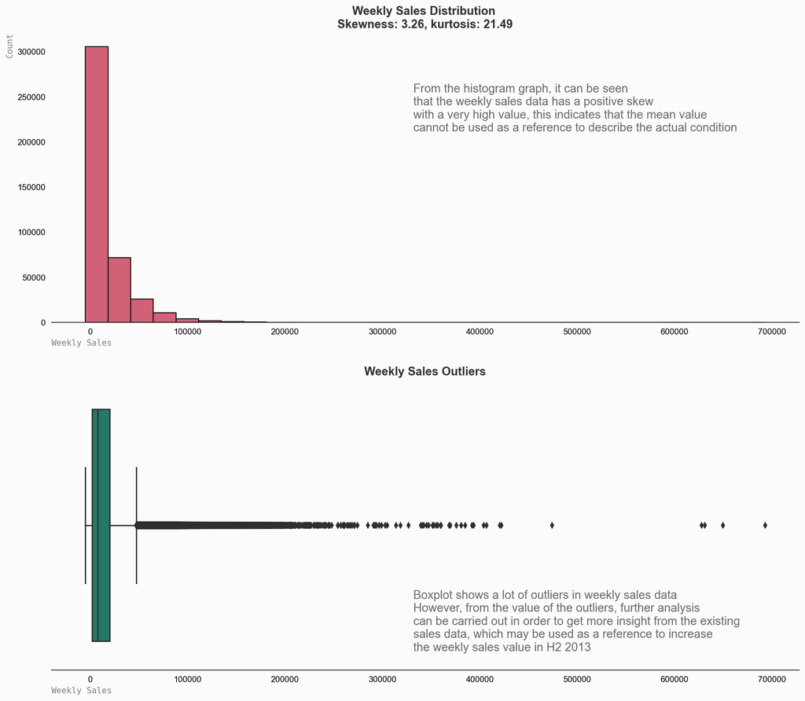

```python
fig, axes = plt.subplots(2, 1, figsize=(16,14), dpi=150, facecolor=background_color)
sns.histplot(data=df, x="Weekly_Sales", bins=30, color=color1,ec='black', ax=axes[0])
axes[0].set_title('Weekly Sales Distribution \nSkewness: {}, kurtosis: {}'.format(round(df['Weekly_Sales'].skew(),2), round(df['Weekly_Sales'].kurtosis(),2)), fontsize=14, fontweight='bold', fontfamily='sans-serif',color='#323232')
axes[0].tick_params(axis='both', which='both',left=False, bottom=False,labelbottom=True)
axes[0].set_facecolor(background_color)
axes[0].set_xlabel('Weekly Sales', fontfamily='monospace', loc='left',color='gray')
axes[0].set_ylabel('Count', fontfamily='monospace', loc='top',color='gray')

sns.boxplot(data=df, x="Weekly_Sales", color=color2, ax=axes[1])
axes[1].set_title('Weekly Sales Outliers', fontsize=14, fontweight='bold', fontfamily='sans-serif',color='#323232')
axes[1].set_facecolor(background_color)
axes[1].set_xlabel('Weekly Sales', fontfamily='monospace', loc='left',color='gray')
axes[1].tick_params(axis='both', which='both',left=False, bottom=False,labelbottom=True)


plt.figtext(0.5, 0.82,
            'From the histogram graph, it can be seen \nthat the weekly sales data has a positive skew \nwith a very high value, this indicates that the mean value \ncannot be used as a reference to describe the actual condition',
            ha='left', va='top', fontsize=14,color='#686A6C')
plt.figtext(0.5, 0.22,
            'Boxplot shows a lot of outliers in weekly sales data \nHowever, from the value of the outliers, further analysis \ncan be carried out in order to get more insight from the existing \nsales data, which may be used as a reference to increase \nthe weekly sales value in H2 2013',
            ha='left', va='top', fontsize=14,color='#686A6C')

for s in ["top","right","left"]:
    axes[0].spines[s].set_visible(False)
    axes[1].spines[s].set_visible(False)

plt.show()
```

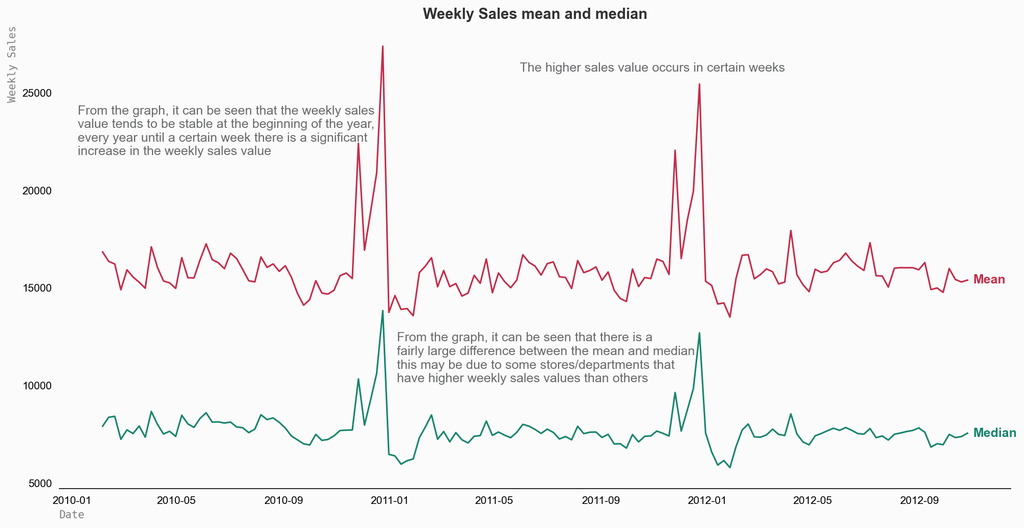

```python
weekly_sales_mean = df.groupby('Date')['Weekly_Sales'].mean().reset_index()
weekly_sales_median = df.groupby('Date')['Weekly_Sales'].median().reset_index()
legends = ['Mean', 'Median']

fig, axes = plt.subplots(figsize=(16,8), dpi=150, facecolor=background_color)
axes.set_title('Weekly Sales mean and median', fontsize=14, fontweight='bold', fontfamily='sans-serif',color='#323232')
sns.lineplot(data=weekly_sales_mean, x="Date", y="Weekly_Sales", color=color1, label='Mean')
sns.lineplot(data=weekly_sales_median, x="Date", y="Weekly_Sales", color=color2, label='Median')
axes.set_facecolor(background_color)
axes.tick_params(axis='both', which='both',left=False, bottom=False,labelbottom=True)
axes.set_xlabel('Date', fontfamily='monospace', loc='left', color='gray')
axes.set_ylabel('Weekly Sales', fontfamily='monospace', loc='top',color='gray')

for s in ["top","right", "left"]:
    axes.spines[s].set_visible(False)

for line in axes.lines:
    data_x, data_y = line.get_data()
    axes.annotate(
        line.get_label(),
        xy=(data_x[-1], data_y[-1]),
        xytext=(5, 0),
        textcoords="offset points",
        va="center",
        size=12, weight='bold',
        color=line.get_color(),
    )
axes.legend().set_visible(False)

plt.figtext(0.14, 0.75,
            'From the graph, it can be seen that the weekly sales \nvalue tends to be stable at the beginning of the year, \nevery year until a certain week there is a significant \nincrease in the weekly sales value',
            ha='left', va='top', fontsize=12,color='#686A6C')
plt.figtext(0.4, 0.38,
            'From the graph, it can be seen that there is a \nfairly large difference between the mean and median \nthis may be due to some stores/departments that \nhave higher weekly sales values than others',
            ha='left', va='top', fontsize=12,color='#686A6C')
plt.figtext(0.5, 0.82,
            'The higher sales value occurs in certain weeks',
            ha='left', va='top', fontsize=12,color='#686A6C')

plt.show()
```

# Sales per Store dan Department

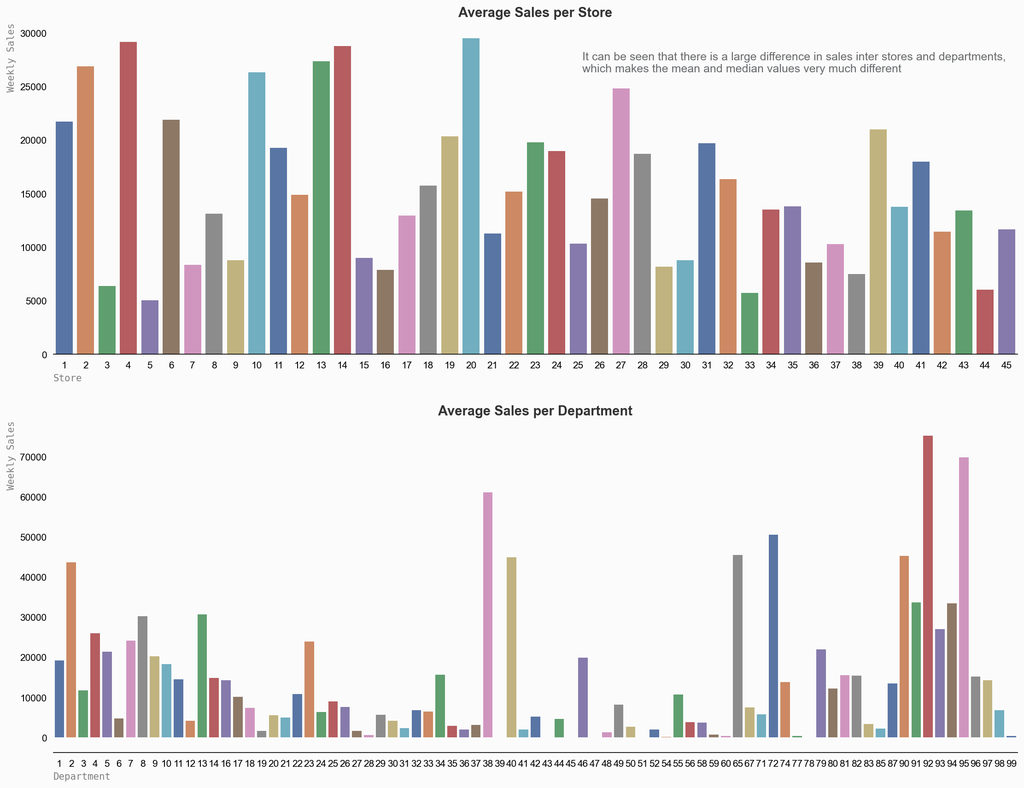

```python
store_weekly_sales = df.groupby('Store')['Weekly_Sales'].mean().reset_index()
dept_weekly_sales = df.groupby('Dept')['Weekly_Sales'].mean().reset_index()
dept_weekly_sales = dept_weekly_sales[dept_weekly_sales.Dept != 0]

fig, axes = plt.subplots(2, 1, figsize=(18,14), dpi=150, facecolor=background_color)
sns.barplot(data=store_weekly_sales, x="Store", y="Weekly_Sales", palette='deep', ax=axes[0])
axes[0].set_title('Average Sales per Store', fontsize=14, fontweight='bold', fontfamily='sans-serif',color='#323232')
axes[0].set_facecolor(background_color)
axes[0].set_xlabel('Store', fontfamily='monospace', loc='left',color='gray')
axes[0].set_ylabel('Weekly Sales', fontfamily='monospace', loc='top',color='gray')
axes[0].tick_params(axis='both', which='both',left=False, bottom=False,labelbottom=True)

sns.barplot(data=dept_weekly_sales, x="Dept", y="Weekly_Sales", palette='deep', ax=axes[1])
axes[1].set_title('Average Sales per Department', fontsize=14, fontweight='bold', fontfamily='sans-serif',color='#323232')
axes[1].set_facecolor(background_color)
axes[1].set_xlabel('Department', fontfamily='monospace', loc='left',color='gray')
axes[1].set_ylabel('Weekly Sales', fontfamily='monospace', loc='top',color='gray')
axes[1].tick_params(axis='both', which='both',left=False, bottom=False,labelbottom=True)

for s in ["top","right", "left"]:
    axes[0].spines[s].set_visible(False)
    axes[1].spines[s].set_visible(False)

plt.figtext(0.55, 0.85,
            'It can be seen that there is a large difference in sales inter stores and departments, \nwhich makes the mean and median values very much different',
            ha='left', va='top', fontsize=12,color='#686A6C')

plt.show()
```

# Weekly sales data for H1 and H2 every year

```python
df.groupby(['Year','Half'])['Weekly_Sales'].describe().transpose()
```

| Year Half | 2010 H1 | 2010 H2 | 2011 H1 | 2011 H2 | 2012 H1 | 2012 H2 |
| --- | --- | --- | --- | --- | --- | --- |
| count | 61657.000000 | 79022.000000 | 73538.000000 | 79915.000000 | 77110.000000 | 50328.000000 |
| mean | 15936.913251 | 16530.382174 | 15330.030696 | 16528.313959 | 15701.795051 | 15684.458810 |
| std | 21927.644045 | 23908.740728 | 21528.744953 | 24017.610242 | 22219.833979 | 21967.760505 |
| min | -1750.000000 | -4988.940000 | -1321.480000 | -3924.000000 | -1699.000000 | -771.900000 |
| 25% | 2200.960000 | 2266.022500 | 2000.645000 | 2111.725000 | 1932.025000 | 1940.080000 |
| 50% | 7954.250000 | 7973.120000 | 7322.695000 | 7701.750000 | 7331.505000 | 7425.310000 |
| 75% | 20184.860000 | 20941.900000 | 19297.510000 | 20834.895000 | 19868.762500 | 19931.332500 |
| max | 293966.050000 | 693099.360000 | 222651.020000 | 649770.180000 | 233140.320000 | 194032.480000 |

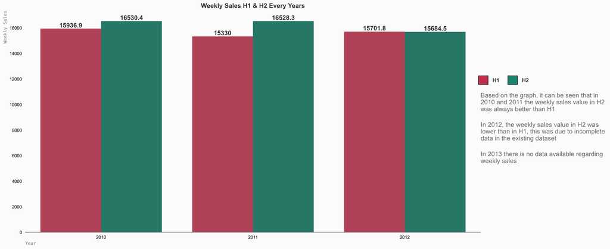

```python
fig, axes = plt.subplots(figsize=(18,9), dpi=300, facecolor=background_color)
axes.set_title('Weekly Sales H1 & H2 Every Years', fontsize=14, fontweight='bold', fontfamily='sans-serif',color='#323232')
sns.barplot(data=df, x="Year", y="Weekly_Sales", hue="Half",ci=None, palette=[color1, color2])
axes.set_facecolor(background_color)
axes.set_xlabel('Year', fontfamily='monospace', loc='left', color='gray')
axes.set_ylabel("Weekly Sales", fontfamily='monospace', loc='top', color='gray')
axes.tick_params(axis='both', which='both',left=False, bottom=False,labelbottom=True)
axes.legend().set_visible(False)

for container in axes.containers:
    axes.bar_label(container, fontsize=14, fontweight='bold', fontfamily='sans-serif', color='#323232')

for s in ["top","right","left"]:
    axes.spines[s].set_visible(False)

plt.figtext(0.9, 0.65, '    ', bbox={'fc':color1, 'pad':5}, ha='left', va='top')
plt.figtext(0.92, 0.65, 'H1', ha='left', va='top', fontsize=12, fontweight='bold', fontfamily='sans-serif',color='#323232')
plt.figtext(0.95, 0.65, '    ', bbox={'fc':color2, 'pad':5}, ha='left', va='top')
plt.figtext(0.97, 0.65, 'H2', ha='left', va='top', fontsize=12, fontweight='bold', fontfamily='sans-serif',color='#323232')

plt.figtext(0.9, 0.6,
            'Based on the graph, it can be seen that in \n2010 and 2011 the weekly sales value in H2 \nwas always better than H1',
            ha='left', va='top', fontsize=14,color='#686A6C')
plt.figtext(0.9, 0.5,
            'In 2012, the weekly sales value in H2 was \nlower than in H1, this was due to incomplete \ndata in the existing dataset',
            ha='left', va='top', fontsize=14,color='#686A6C')
plt.figtext(0.9, 0.4,
            'In 2013 there is no data available regarding \nweekly sales',
            ha='left', va='top', fontsize=14,color='#686A6C')

plt.show()
```

# Weekly sales data for every quarter in every year

```python
df.groupby(['Year','Quarter'])['Weekly_Sales'].describe().transpose()
```

| Year Quarter | 2010 1 | 2010 2 | 2010 3 | 2010 4 | 2011 1 | 2011 2 | 2011 3 | 2011 4 | 2012 1 | 2012 2 | 2012 3 | 2012 4 |
| --- | --- | --- | --- | --- | --- | --- | --- | --- | --- | --- | --- | --- |
| count | 23627.000000 | 38030.000000 | 37888.000000 | 41134.000000 | 35249.000000 | 38289.000000 | 41147.000000 | 38768.000000 | 38646.000000 | 38464.000000 | 38453.000000 | 11875.000000 |
| mean | 15755.397873 | 16049.683796 | 15769.851490 | 17230.897235 | 15018.631535 | 15616.705955 | 15538.398171 | 17578.975972 | 15330.634521 | 16074.711800 | 15733.642695 | 15525.194141 |
| std | 22240.257196 | 21730.691772 | 21535.616515 | 25883.446581 | 21665.334825 | 21398.506320 | 21752.888758 | 26167.441755 | 22232.788977 | 22200.850515 | 22016.221195 | 21810.260166 |
| min | -1750.000000 | -698.000000 | -1098.000000 | -4988.940000 | -1321.480000 | -594.000000 | -3924.000000 | -798.000000 | -1699.000000 | -548.000000 | -771.900000 | -289.000000 |
| 25% | 2098.855000 | 2281.455000 | 2162.805000 | 2353.982500 | 1900.850000 | 2124.580000 | 1963.785000 | 2267.030000 | 1824.955000 | 2070.370000 | 1905.820000 | 2081.350000 |
| 50% | 7793.600000 | 8053.150000 | 7806.570000 | 8190.110000 | 7029.690000 | 7593.980000 | 7373.910000 | 8142.325000 | 7052.535000 | 7591.170000 | 7424.820000 | 7438.510000 |
| 75% | 19686.345000 | 20528.840000 | 20263.132500 | 21557.632500 | 18371.790000 | 20183.470000 | 19789.530000 | 22115.457500 | 18910.750000 | 20714.860000 | 20021.350000 | 19567.325000 |
| max | 293966.050000 | 206160.360000 | 205314.670000 | 693099.360000 | 222651.020000 | 206017.230000 | 241120.000000 | 649770.180000 | 233140.320000 | 224917.940000 | 194032.480000 | 192860.850000 |

[figure not shown]

```python
fig, axes = plt.subplots(figsize=(18,9), dpi=300, facecolor=background_color)
axes.set_title('Weekly Sales H1 & H2 Every Years', fontsize=14, fontweight='bold', fontfamily='sans-serif',color='#323232')
sns.barplot(data=df, x="Year", y="Weekly_Sales", hue="Quarter",ci=None, palette=[color1, color2, '#98AFC7', '#FFDB58'])
axes.set_facecolor(background_color)
axes.set_xlabel('Year', fontfamily='monospace', loc='left', color='gray')
axes.set_ylabel("Weekly Sales", fontfamily='monospace', loc='top', color='gray')
axes.tick_params(axis='both', which='both',left=False, bottom=False,labelbottom=True)
axes.legend().set_visible(False)

for container in axes.containers:
    axes.bar_label(container, fontsize=14, fontweight='bold', fontfamily='sans-serif', color='#323232')

for s in ["top","right","left"]:
    axes.spines[s].set_visible(False)

plt.figtext(0.7, 0.88, '    ', bbox={'fc':color1, 'pad':5}, ha='left', va='top')
plt.figtext(0.72, 0.88, 'Q1', ha='left', va='top', fontsize=12, fontweight='bold', fontfamily='sans-serif',color='#323232')
plt.figtext(0.75, 0.88, '    ', bbox={'fc':color2, 'pad':5}, ha='left', va='top')
plt.figtext(0.77, 0.88, 'Q2', ha='left', va='top', fontsize=12, fontweight='bold', fontfamily='sans-serif',color='#323232')
plt.figtext(0.8, 0.88, '    ', bbox={'fc':'#98AFC7', 'pad':5}, ha='left', va='top')
plt.figtext(0.82, 0.88, 'Q3', ha='left', va='top', fontsize=12, fontweight='bold', fontfamily='sans-serif',color='#323232')
plt.figtext(0.85, 0.88, '    ', bbox={'fc':'#FFDB58', 'pad':5}, ha='left', va='top')
plt.figtext(0.87, 0.88, 'Q4', ha='left', va='top', fontsize=12, fontweight='bold', fontfamily='sans-serif',color='#323232')

plt.show()
```

# Weekly sales will be higher during the holiday week

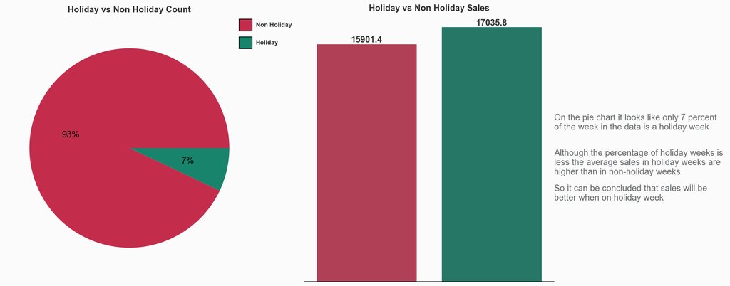

```python
holiday_counts = df['IsHoliday'].value_counts().reset_index()
holiday_weekly_sales = df.groupby('IsHoliday')['Weekly_Sales'].mean().reset_index()

fig, axes = plt.subplots(1, 2, figsize=(16,8), dpi=150, facecolor=background_color)
patches, texts, pcts = axes[0].pie(holiday_counts['IsHoliday'],
                                 colors = [color1, color2],
                                 autopct='%.0f%%',
                                 textprops={'size': 'x-large'})
axes[0].set_title('Holiday vs Non Holiday Count',y=1.03, fontsize=14, fontweight='bold', fontfamily='sans-serif',color='#323232')
for i, patch in enumerate(patches):
    texts[i].set_color(patch.get_facecolor())

sns.barplot(data=holiday_weekly_sales, x="IsHoliday", y='Weekly_Sales',ci=None, palette=[color1, color2], ax=axes[1])
axes[1].bar_label(axes[1].containers[0], fontsize=14, fontweight='bold', fontfamily='sans-serif', color='#323232')
axes[1].set_facecolor(background_color)
axes[1].set_title('Holiday vs Non Holiday Sales', fontsize=14, fontweight='bold', fontfamily='sans-serif',color='#323232')
axes[1].get_xaxis().set_visible(False)
axes[1].get_yaxis().set_visible(False)
axes[1].tick_params(axis='both', which='both',left=False, bottom=False,labelbottom=True)

for s in ["top","right","left"]:
    axes[1].spines[s].set_visible(False)

plt.figtext(0.465, 0.85, '    ', bbox={'fc':color1, 'pad':5}, ha='center', va='center')
plt.figtext(0.505, 0.85, 'Non Holiday', ha='center', va='center', fontsize=10, fontweight='bold', fontfamily='sans-serif',color='#323232')
plt.figtext(0.465, 0.8, '    ', bbox={'fc':color2, 'pad':5}, ha='center', va='center')
plt.figtext(0.495, 0.8, 'Holiday', ha='center', va='center', fontsize=10, fontweight='bold', fontfamily='sans-serif',color='#323232')
plt.figtext(0.9, 0.6,
            'On the pie chart it looks like only 7 percent \nof the week in the data is a holiday week',
            ha='left', va='top', fontsize=14,color='#686A6C')
plt.figtext(0.9, 0.5,
            'Although the percentage of holiday weeks is \nless the average sales in holiday weeks are \nhigher than in non-holiday weeks',
            ha='left', va='top', fontsize=14,color='#686A6C')
plt.figtext(0.9, 0.4,
            'So it can be concluded that sales will be \nbetter when on holiday week',
            ha='left', va='top', fontsize=14,color='#686A6C')

plt.show()
```

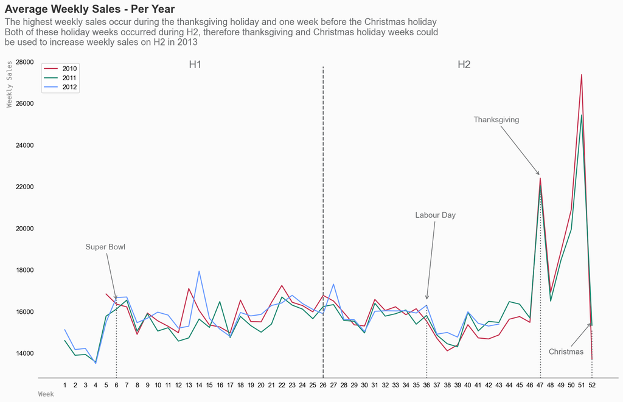

```python
weekly_sales_2010 = df[df.Year==2010]['Weekly_Sales'].groupby(df['Week']).mean().reset_index()
weekly_sales_2011 = df[df.Year==2011]['Weekly_Sales'].groupby(df['Week']).mean().reset_index()
weekly_sales_2012 = df[df.Year==2012]['Weekly_Sales'].groupby(df['Week']).mean().reset_index()

fig, axes = plt.subplots(figsize=(16,9), dpi=150, facecolor=background_color)
#axes.set_title('Average Weekly Sales - Per Year', fontsize=14, fontweight='bold', fontfamily='sans-serif',color='#323232')
sns.lineplot(data=weekly_sales_2010, x="Week", y="Weekly_Sales", color=color1, label='2010')
sns.lineplot(data=weekly_sales_2011, x="Week", y="Weekly_Sales", color=color2, label='2011')
sns.lineplot(data=weekly_sales_2012, x="Week", y="Weekly_Sales", color=color3, label='2012')
axes.set_facecolor(background_color)
axes.tick_params(axis='both', which='both',left=False, bottom=False,labelbottom=True)
axes.set_xlabel('Week', fontfamily='monospace', loc='left', color='gray')
axes.set_ylabel('Weekly Sales', fontfamily='monospace', loc='top', color='gray')
plt.xticks(np.arange(1, 53, step=1))

axes.axvline(x = 6, ymax=0.25, color = '#686A6C', linestyle=':')
axes.axvline(x = 26, ymax=0.98, color = '#686A6C', linestyle='--')
axes.axvline(x = 36, ymax=0.235, color = '#686A6C', linestyle=':')
axes.axvline(x = 47, ymax=0.6, color = '#686A6C', linestyle=':')
axes.axvline(x = 52, ymax=0.15, color = '#686A6C', linestyle=':')

axes.text(13, 27700, 'H1', fontsize = 16, color = '#686A6C')
axes.text(39, 27700, 'H2', fontsize = 16, color = '#686A6C')

axes.annotate('Super Bowl', xy=(6, 16500),  xycoords='data',
            xytext=(0.15, 0.4), textcoords='axes fraction',
            arrowprops=dict(arrowstyle="->",connectionstyle="arc3", color="#686A6C"),
            horizontalalignment='right', verticalalignment='bottom',size=12, color='#686A6C'
            )
axes.annotate('Labour Day', xy=(36, 16500),  xycoords='data',
            xytext=(0.65, 0.5), textcoords='axes fraction',
            arrowprops=dict(arrowstyle="->",connectionstyle="arc3", color="#686A6C"),
            horizontalalignment='left', verticalalignment='bottom',size=12, color='#686A6C'
            )
axes.annotate('Thanksgiving', xy=(47, 22500),  xycoords='data',
            xytext=(0.75, 0.8), textcoords='axes fraction',
            arrowprops=dict(arrowstyle="->",connectionstyle="arc3", color="#686A6C"),
            horizontalalignment='left', verticalalignment='bottom',size=12, color='#686A6C'
            )
axes.annotate('Christmas', xy=(52, 15500),  xycoords='data',
            xytext=(0.88, 0.07), textcoords='axes fraction',
            arrowprops=dict(arrowstyle="->",connectionstyle="arc3", color="#686A6C"),
            horizontalalignment='left', verticalalignment='bottom',size=12, color='#686A6C'
            )

for s in ["top","right", "left"]:
    axes.spines[s].set_visible(False)


plt.figtext(0.08, 1,
            'Average Weekly Sales - Per Year',
            ha='left', va='center', fontsize=17, fontweight='bold', fontfamily='sans-serif',color='#323232')
plt.figtext(0.08, 0.98,
            'The highest weekly sales occur during the thanksgiving holiday and one week before the Christmas holiday \nBoth of these holiday weeks occurred during H2, therefore thanksgiving and Christmas holiday weeks could \nbe used to increase weekly sales on H2 in 2013',
            ha='left', va='top', fontsize=14,color='#686A6C')

plt.show()
```

# ASSUMPTION #1

- The higher the markdown value, the higher the weekly sales

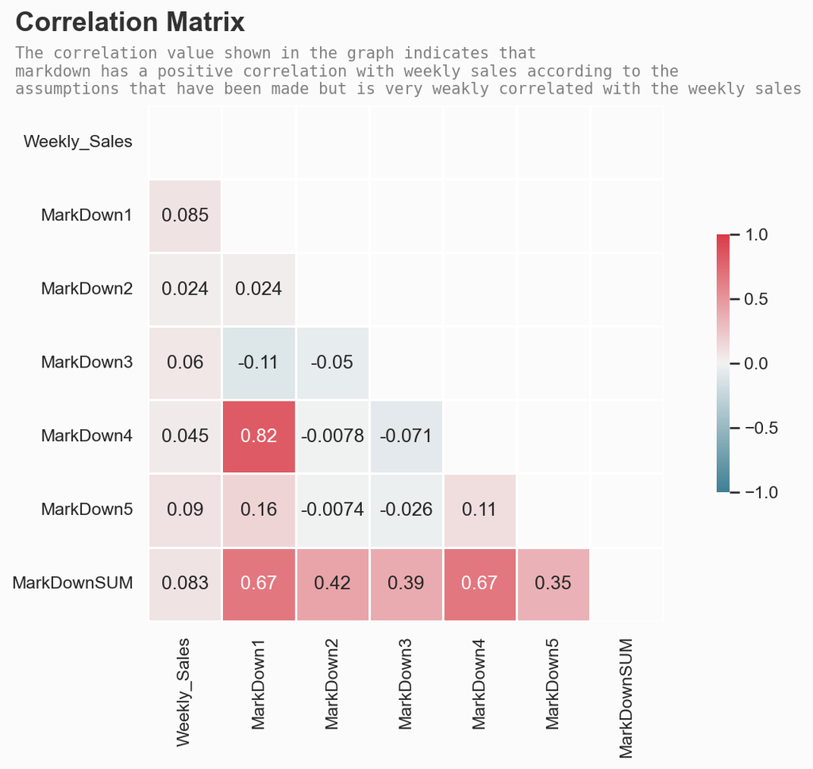

```python
sns.set(style="white")

corr = df[["Weekly_Sales","MarkDown1","MarkDown2","MarkDown3","MarkDown4","MarkDown5","MarkDownSUM"]].corr()
mask = np.triu(np.ones_like(corr, dtype=np.bool))

fig, axes = plt.subplots(figsize=(12,6), dpi=150, facecolor=background_color)
cmap = sns.diverging_palette(220, 10, as_cmap=True)
sns.heatmap(corr, mask=mask, cmap=cmap, vmax=1, vmin=-1, center=0,
            square=True, linewidths=.5, cbar_kws={"shrink": .5}, annot=True)
axes.set_facecolor(background_color)

plt.figtext(0.27, 1, 'Correlation Matrix', ha='left', va='center', fontsize=17, fontweight='bold', fontfamily='sans-serif',color='#323232')
plt.figtext(0.27, 0.93, 'The correlation value shown in the graph indicates that \nmarkdown has a positive correlation with weekly sales according to the \nassumptions that have been made but is very weakly correlated with the weekly sales', ha='left', va='center', fontsize=10, fontweight='light', fontfamily='monospace',color='gray')

plt.show()
```

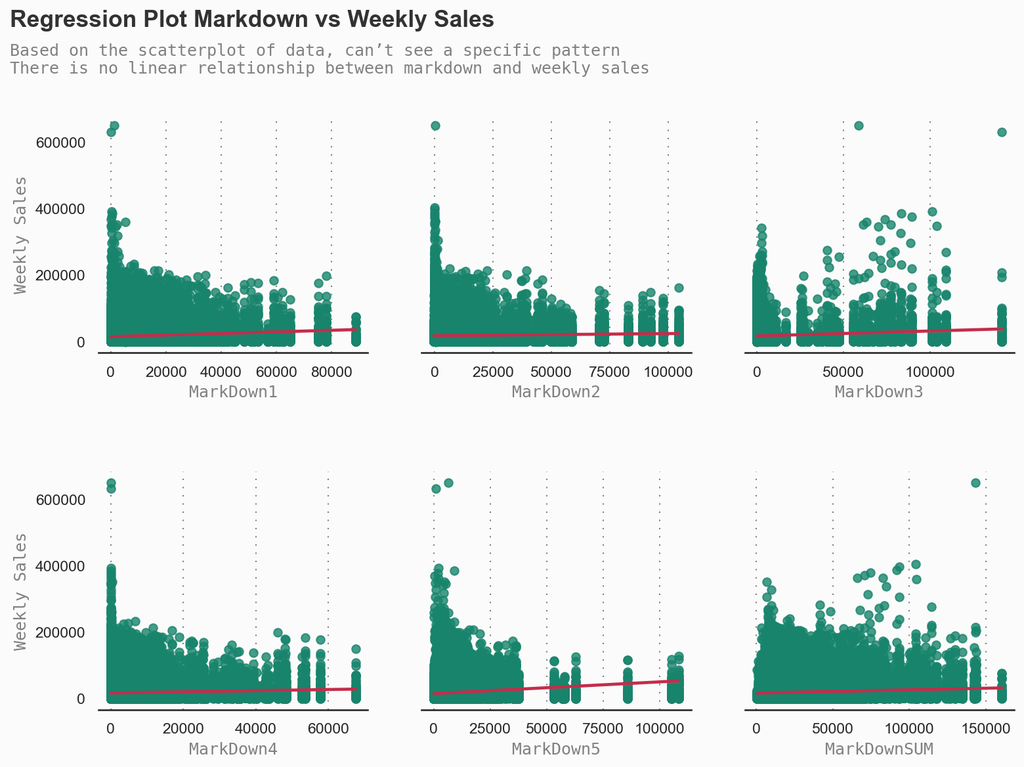

```python
MarkDown_list = ["MarkDown1","MarkDown2","MarkDown3","MarkDown4","MarkDown5","MarkDownSUM"]

fig = plt.figure(figsize=(12, 8), dpi=150,facecolor=background_color)
gs = fig.add_gridspec(2, 3)
gs.update(wspace=0.2, hspace=0.5)


plot = 0
for row in range(0, 2):
    for col in range(0, 3):
        locals()["ax"+str(plot)] = fig.add_subplot(gs[row, col])
        locals()["ax"+str(plot)].set_facecolor(background_color)
        locals()["ax"+str(plot)].set_axisbelow(True)
        locals()["ax"+str(plot)].tick_params(axis='y', left=False)
        if not (plot == 0 or plot == 3):
            locals()["ax"+str(plot)].get_yaxis().set_visible(False)
        for s in ["top","right", "left"]:
            locals()["ax"+str(plot)].spines[s].set_visible(False)
        plot += 1

plot = 0

for md in MarkDown_list:
    sns.regplot(data=df, x=md, y="Weekly_Sales",color=color2,line_kws={"color": color1}, ax=locals()["ax"+str(plot)])
    locals()["ax"+str(plot)].set_xlabel(md, fontfamily='monospace', color='gray')
    locals()["ax"+str(plot)].grid(which='major', axis='x', zorder=0, color='gray', linestyle=':', dashes=(1,5))
    if plot == 0 or plot == 3:
        locals()["ax"+str(plot)].set_ylabel("Weekly Sales", fontfamily='monospace', color='gray')
    plot += 1

plt.figtext(0.05, 1, 'Regression Plot Markdown vs Weekly Sales', ha='left', va='center', fontsize=17, fontweight='bold', fontfamily='sans-serif',color='#323232')
plt.figtext(0.05, 0.95, 'Based on the scatterplot of data, can’t see a specific pattern\nThere is no linear relationship between markdown and weekly sales', ha='left', va='center', fontsize=12, fontweight='light', fontfamily='monospace',color='gray')

plt.show()
```

# ASSUMPTION #2

- The higher the temperature value, the lower the weekly sales
- The higher the fuel price value, the lower the weekly sales
- The higher the unemployment rate, the lower the weekly sales
- The higher the CPI value, the lower the weekly sales

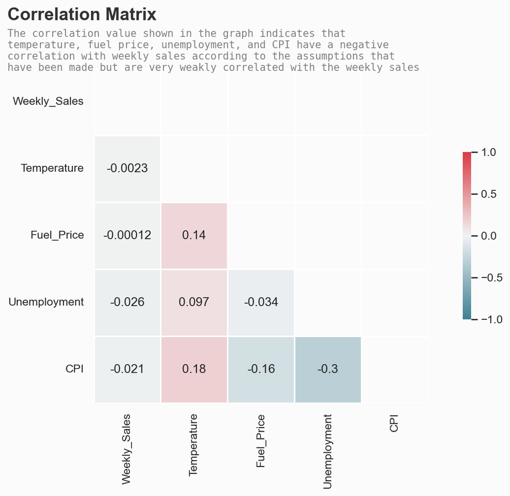

```python
sns.set(style="white")

corr = df[["Weekly_Sales","Temperature","Fuel_Price","Unemployment", "CPI"]].corr()
mask = np.triu(np.ones_like(corr, dtype=np.bool))

fig, axes = plt.subplots(figsize=(12,6), dpi=150, facecolor=background_color)
cmap = sns.diverging_palette(220, 10, as_cmap=True)
sns.heatmap(corr, mask=mask, cmap=cmap, vmax=1, vmin=-1, center=0,
            square=True, linewidths=.5, cbar_kws={"shrink": .5}, annot=True)
axes.set_facecolor(background_color)

plt.figtext(0.27, 1, 'Correlation Matrix', ha='left', va='center', fontsize=17, fontweight='bold', fontfamily='sans-serif',color='#323232')
plt.figtext(0.27, 0.92, 'The correlation value shown in the graph indicates that \ntemperature, fuel price, unemployment, and CPI have a negative \ncorrelation with weekly sales according to the assumptions that \nhave been made but are very weakly correlated with the weekly sales', ha='left', va='center', fontsize=10, fontweight='light', fontfamily='monospace',color='gray')

plt.show()
```

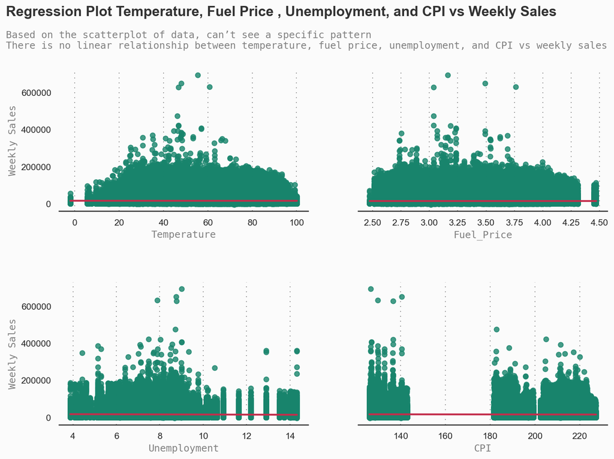

```python
assum_list = ["Temperature","Fuel_Price","Unemployment", "CPI"]

fig = plt.figure(figsize=(12, 8), dpi=150,facecolor=background_color)
gs = fig.add_gridspec(2, 2)
gs.update(wspace=0.2, hspace=0.5)


plot = 0
for row in range(0, 2):
    for col in range(0, 2):
        locals()["ax"+str(plot)] = fig.add_subplot(gs[row, col])
        locals()["ax"+str(plot)].set_facecolor(background_color)
        locals()["ax"+str(plot)].set_axisbelow(True)
        locals()["ax"+str(plot)].tick_params(axis='y', left=False)
        if not (plot == 0 or plot == 2):
            locals()["ax"+str(plot)].get_yaxis().set_visible(False)
        for s in ["top","right", "left"]:
            locals()["ax"+str(plot)].spines[s].set_visible(False)
        plot += 1

plot = 0

for md in assum_list:
    sns.regplot(data=df, x=md, y="Weekly_Sales",color=color2,line_kws={"color": color1}, ax=locals()["ax"+str(plot)])
    locals()["ax"+str(plot)].set_xlabel(md, fontfamily='monospace', color='gray')
    locals()["ax"+str(plot)].grid(which='major', axis='x', zorder=0, color='gray', linestyle=':', dashes=(1,5))
    if plot == 0 or plot == 2:
        locals()["ax"+str(plot)].set_ylabel("Weekly Sales", fontfamily='monospace', color='gray')
    plot += 1

plt.figtext(0.05, 1, 'Regression Plot Temperature, Fuel Price , Unemployment, and CPI vs Weekly Sales', ha='left', va='center', fontsize=17, fontweight='bold', fontfamily='sans-serif',color='#323232')
plt.figtext(0.05, 0.94, 'Based on the scatterplot of data, can’t see a specific pattern \nThere is no linear relationship between temperature, fuel price, unemployment, and CPI vs weekly sales', ha='left', va='center', fontsize=12, fontweight='light', fontfamily='monospace',color='gray')

plt.show()
```

# ASSUMPTION #3

- The higher the size value, the higher the weekly sales
- The higher the week value, the higher the weekly sales

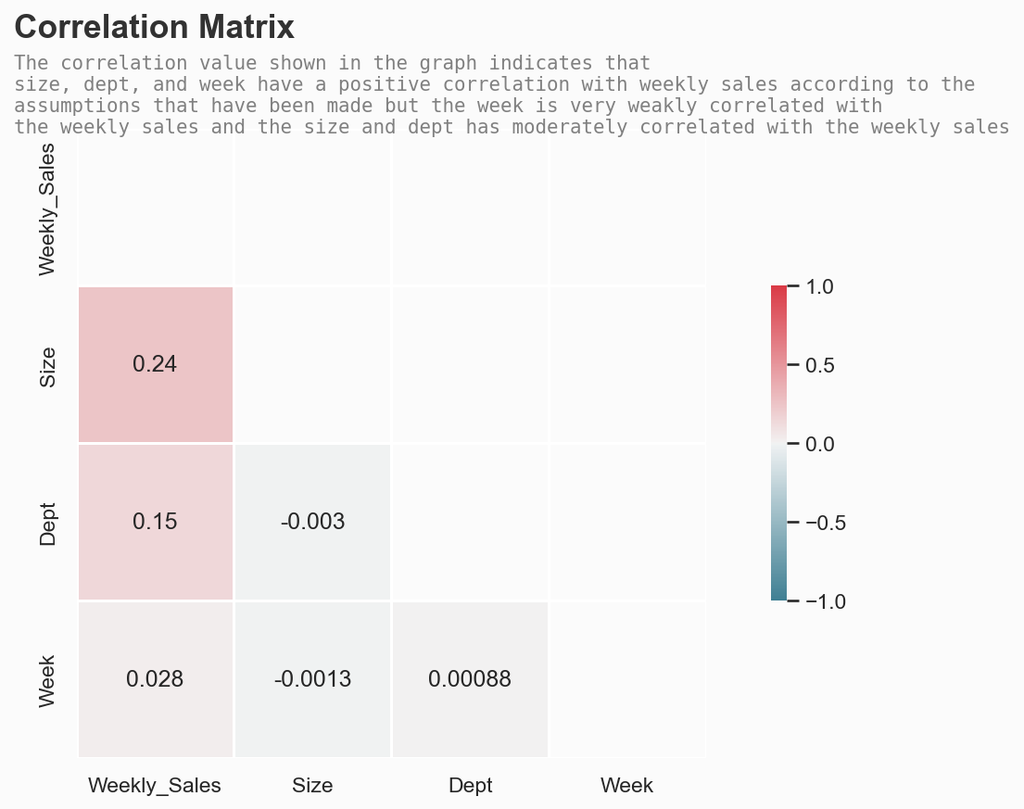

```python
sns.set(style="white")

corr = df[["Weekly_Sales","Size","Dept","Week"]].corr()
mask = np.triu(np.ones_like(corr, dtype=np.bool))

fig, axes = plt.subplots(figsize=(12,6), dpi=150, facecolor=background_color)
cmap = sns.diverging_palette(220, 10, as_cmap=True)
sns.heatmap(corr, mask=mask, cmap=cmap, vmax=1, vmin=-1, center=0,
            square=True, linewidths=.5, cbar_kws={"shrink": .5}, annot=True)
axes.set_facecolor(background_color)

plt.figtext(0.33, 1, 'Correlation Matrix', ha='left', va='center', fontsize=17, fontweight='bold', fontfamily='sans-serif',color='#323232')
plt.figtext(0.33, 0.92, 'The correlation value shown in the graph indicates that \nsize, dept, and week have a positive correlation with weekly sales according to the \nassumptions that have been made but the week is very weakly correlated with \nthe weekly sales and the size and dept has moderately correlated with the weekly sales', ha='left', va='center', fontsize=10, fontweight='light', fontfamily='monospace',color='gray')

plt.show()
```

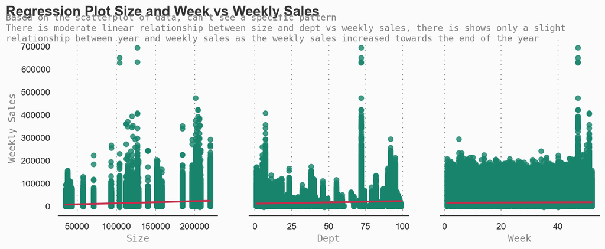

```python
assum_list1 = ["Size","Dept", "Week"]

fig = plt.figure(figsize=(12, 4), dpi=150,facecolor=background_color)
gs = fig.add_gridspec(1, 3)
gs.update(wspace=0.2, hspace=0.5)


plot = 0
for row in range(0, 1):
    for col in range(0, 3):
        locals()["ax"+str(plot)] = fig.add_subplot(gs[row, col])
        locals()["ax"+str(plot)].set_facecolor(background_color)
        locals()["ax"+str(plot)].set_axisbelow(True)
        locals()["ax"+str(plot)].tick_params(axis='y', left=False)
        if not (plot == 0 or plot == 3):
            locals()["ax"+str(plot)].get_yaxis().set_visible(False)
        for s in ["top","right", "left"]:
            locals()["ax"+str(plot)].spines[s].set_visible(False)
        plot += 1

plot = 0

for md in assum_list1:
    sns.regplot(data=df, x=md, y="Weekly_Sales",color=color2,line_kws={"color": color1}, ax=locals()["ax"+str(plot)])
    locals()["ax"+str(plot)].set_xlabel(md, fontfamily='monospace', color='gray')
    locals()["ax"+str(plot)].grid(which='major', axis='x', zorder=0, color='gray', linestyle=':', dashes=(1,5))
    if plot == 0 or plot == 3:
        locals()["ax"+str(plot)].set_ylabel("Weekly Sales", fontfamily='monospace', color='gray')
    plot += 1

plt.figtext(0.05, 1, 'Regression Plot Size and Week vs Weekly Sales', ha='left', va='center', fontsize=17, fontweight='bold', fontfamily='sans-serif',color='#323232')
plt.figtext(0.05, 0.93, 'Based on the scatterplot of data, can’t see a specific pattern \nThere is moderate linear relationship between size and dept vs weekly sales, there is shows only a slight \nrelationship between year and weekly sales as the weekly sales increased towards the end of the year', ha='left', va='center', fontsize=11, fontweight='light', fontfamily='monospace',color='gray')

plt.show()
```

# Data Preparation for Model Training

```python
testData = pd.read_csv('test.csv')
trainData = df.copy()
features = pd.read_csv('features.csv')
stores = pd.read_csv('stores.csv')

featuresData = features.merge(stores, how='inner', on='Store')
```

```python
featuresData['MarkDownSUM'] = featuresData['MarkDown1'] + featuresData['MarkDown2'] + featuresData['MarkDown3'] + featuresData['MarkDown4'] + featuresData['MarkDown5']
featuresData['Date'] = pd.to_datetime(featuresData['Date'])
featuresData['Week'] = featuresData['Date'].dt.week
featuresData['Month'] = featuresData['Date'].dt.month
featuresData['Quarter'] = featuresData['Date'].dt.quarter
featuresData['Half'] = featuresData['Month'].apply(lambda x: 'H1' if x <= 6 else 'H2')
featuresData['Year'] = featuresData['Date'].dt.year
featuresData.head(2)
```

|  | Store | Date | Temperature | Fuel_Price | MarkDown1 | MarkDown2 | MarkDown3 | MarkDown4 | MarkDown5 | CPI | Unemployment | IsHoliday | Type | Size | MarkDownSUM | Week | Month | Quarter | Half | Year |
| --- | --- | --- | --- | --- | --- | --- | --- | --- | --- | --- | --- | --- | --- | --- | --- | --- | --- | --- | --- | --- |
| 0 | 1 | 2010-02-05 | 42.31 | 2.572 | NaN | NaN | NaN | NaN | NaN | 211.096358 | 8.106 | False | A | 151315 | NaN | 5 | 2 | 1 | H1 | 2010 |
| 1 | 1 | 2010-02-12 | 38.51 | 2.548 | NaN | NaN | NaN | NaN | NaN | 211.242170 | 8.106 | True | A | 151315 | NaN | 6 | 2 | 1 | H1 | 2010 |

```python
testData['Date'] = pd.to_datetime(testData['Date'])
testData.head(2)
```

|  | Store | Dept | Date | IsHoliday |
| --- | --- | --- | --- | --- |
| 0 | 1 | 1 | 2012-11-02 | False |
| 1 | 1 | 1 | 2012-11-09 | False |

```python
testData_detail = testData.merge(featuresData, how='inner', on=['Store','Date','IsHoliday']).sort_values(by=['Store','Dept','Date']).reset_index(drop=True)
testData_detail.head(2)
```

|  | Store | Dept | Date | IsHoliday | Temperature | Fuel_Price | MarkDown1 | MarkDown2 | MarkDown3 | MarkDown4 | ... | CPI | Unemployment | Type | Size | MarkDownSUM | Week | Month | Quarter | Half | Year |
| --- | --- | --- | --- | --- | --- | --- | --- | --- | --- | --- | --- | --- | --- | --- | --- | --- | --- | --- | --- | --- | --- |
| 0 | 1 | 1 | 2012-11-02 | False | 55.32 | 3.386 | 6766.44 | 5147.70 | 50.82 | 3639.90 | ... | 223.462779 | 6.573 | A | 151315 | 18342.28 | 44 | 11 | 4 | H2 | 2012 |
| 1 | 1 | 1 | 2012-11-09 | False | 61.24 | 3.314 | 11421.32 | 3370.89 | 40.28 | 4646.79 | ... | 223.481307 | 6.573 | A | 151315 | 25633.44 | 45 | 11 | 4 | H2 | 2012 |

2 rows × 21 columns

- Markdown1-5 and markdown sum have a very weak correlation with the weekly sales so that we will leave these columns out
- Temperature. Fuel price, CPI, and Unemployment are very weakly correlated with the weekly sales, so these columns will also be dropped out
- IsHoliday and week will be considered for further analysis as the sales in the holiday weeks are higher than in the non-holiday weeks
- Department and Store size has a moderate correlation with the weekly sales

```python
X_train = trainData[['Store','Dept','IsHoliday','Size','Week','Year']]
Y_train = trainData['Weekly_Sales']
```

```python
X_test = testData_detail[['Store','Dept','IsHoliday','Size','Week','Year']]
```

```python
from sklearn.model_selection import train_test_split

train_inputs, val_inputs, train_targets, val_targets = train_test_split(
    X_train, Y_train, test_size=0.3, random_state=12)
```

the evaluation is based on Weighted Mean Absolute Error (WMAE), with a weight of 5 for Holiday Weeks and 1 otherwise.

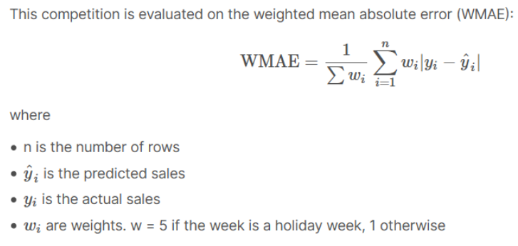

```python
def WMAE(df, targets, predictions):
    weights = df.IsHoliday.apply(lambda x: 5 if x else 1)
    return np.round(np.sum(weights*abs(targets-predictions))/(np.sum(weights)), 2)
```

# Machine Learning

## Linear Regression

```python
from sklearn.linear_model import LinearRegression

# Create and train the model
model = LinearRegression().fit(train_inputs, train_targets)

# Generate predictions on training data
train_preds = model.predict(train_inputs)

# Compute WMAE on traing data
train_wmae = WMAE(train_inputs, train_targets, train_preds)
print('The WMAE loss for the training set is  {}.'.format(train_wmae))

# Generate predictions on validation data
val_preds = model.predict(val_inputs)

# Compute WMAE on validation data
val_wmae = WMAE(val_inputs, val_targets, val_preds)
print('The WMAE loss for the validation set is  {}.'.format(val_wmae))
```

```
The WMAE loss for the training set is  14819.55.
The WMAE loss for the validation set is  14791.34.
```

## Decision Tree

```python
from sklearn.tree import DecisionTreeRegressor

tree = DecisionTreeRegressor()

tree.fit(train_inputs, train_targets)

tree_train_preds = tree.predict(train_inputs)

# Compute WMAE on traing data
tree_train_wmae = WMAE(train_inputs, train_targets, tree_train_preds)
print('The WMAE loss for the training set is  {}.'.format(tree_train_wmae))


# Compute WMAE on validation data
tree_val_preds = tree.predict(val_inputs)
tree_val_wmae = WMAE(val_inputs, val_targets, tree_val_preds)
print('The WMAE loss for the validation set is  {}.'.format(tree_val_wmae))
```

```
The WMAE loss for the training set is  0.0.
The WMAE loss for the validation set is  1872.99.
```

## Random Forest

```python
from sklearn.ensemble import RandomForestRegressor

# Create the model
rf1 = RandomForestRegressor(random_state=12)

# Fit the model
rf1.fit(train_inputs, train_targets)

rf1_train_preds = rf1.predict(train_inputs)

# Compute WMAE on traing data
rf1_train_wmae = WMAE(train_inputs, train_targets, rf1_train_preds)
print('The WMAE loss for the training set is  {}.'.format(rf1_train_wmae))

rf1_val_preds = rf1.predict(val_inputs)

# Compute WMAE on validation data
rf1_val_wmae = WMAE(val_inputs, val_targets, rf1_val_preds)
print('The WMAE loss for the validation set is  {}.'.format(rf1_val_wmae))
```

```
The WMAE loss for the training set is  571.81.
The WMAE loss for the validation set is  1536.69.
```

### Random Forest Parameter Tuning

```python
def RF_I(n_estimators, max_depth):
    result = []
    for estimator in n_estimators:
        for depth in max_depth:
            print('START:', ', n_estimators:', estimator, ', max_depth:', depth)
            model = RandomForestRegressor(n_estimators=estimator, max_depth=depth, random_state=12).fit(train_inputs, train_targets)
            train_wmae = WMAE(train_inputs, train_targets, model.predict(train_inputs))
            val_wmae = WMAE(val_inputs, val_targets, model.predict(val_inputs))
            result.append({'Max_Depth': depth, 'Estimators': estimator,
                           'WMAE (training)': train_wmae, 'WMAE (validation)': val_wmae})
            print('FINISH')
    return pd.DataFrame(result)

def RF_II(n_estimators, max_depth, max_features):
    result = []
    for feature in max_features:
        print('START:' ', max_features:', feature)
        model = RandomForestRegressor(n_estimators=n_estimators, max_depth=max_depth,
                                      max_features=feature, random_state=12).fit(train_inputs, train_targets)
        train_wmae = WMAE(train_inputs, train_targets, model.predict(train_inputs))
        val_wmae = WMAE(val_inputs, val_targets, model.predict(val_inputs))
        result.append({'Max_Feature': feature, 'WMAE (training)': train_wmae, 'WMAE (validation)': val_wmae})
        print('FINISH')
    return pd.DataFrame(result)

def RF_III(n_estimators, max_depth, max_features, min_samples_split, min_samples_leaf):
    result = []
    for split in min_samples_split:
        for leaf in min_samples_leaf:
            print('START:' ', min_samples_split:', split, ', min_samples_leaf:', leaf)
            model = RandomForestRegressor(n_estimators=n_estimators, max_depth=max_depth,
                                          max_features=max_features, min_samples_leaf=leaf,
                                          min_samples_split=split, random_state=12).fit(train_inputs, train_targets)
            train_wmae = WMAE(train_inputs, train_targets, model.predict(train_inputs))
            val_wmae = WMAE(val_inputs, val_targets, model.predict(val_inputs))
            result.append({'Min_Samples_Leaf': leaf, 'Min_Samples_Split': split,
                           'WMAE (training)': train_wmae, 'WMAE (validation)': val_wmae})
            print('FINISH')
    return pd.DataFrame(result)
```

```python
n_estimators = [10, 30, 50, 70, 90, 100, 130]
max_depth = [5, 10, 15, 20, 25, 30, 35]

RF_I(n_estimators, max_depth)
```

[output not shown]

[output cut: 43 more lines]

[output not shown]

|  | Max_Depth | Estimators | WMAE (training) | WMAE (validation) |
| --- | --- | --- | --- | --- |
| 0 | 5 | 10 | 9454.44 | 9396.62 |
| 1 | 10 | 10 | 4339.45 | 4415.29 |
| 2 | 15 | 10 | 1814.18 | 2173.74 |
| 3 | 20 | 10 | 902.75 | 1646.35 |
| 4 | 25 | 10 | 663.92 | 1609.87 |
| 5 | 30 | 10 | 634.59 | 1614.08 |
| 6 | 35 | 10 | 633.28 | 1610.32 |
| 7 | 5 | 30 | 9119.46 | 9069.78 |
| 8 | 10 | 30 | 4293.26 | 4365.68 |
| 9 | 15 | 30 | 1789.88 | 2135.17 |
| 10 | 20 | 30 | 866.20 | 1601.18 |
| 11 | 25 | 30 | 620.38 | 1558.83 |
| 12 | 30 | 30 | 589.36 | 1560.56 |
| 13 | 35 | 30 | 587.88 | 1558.35 |
| 14 | 5 | 50 | 8966.82 | 8922.60 |
| 15 | 10 | 50 | 4256.40 | 4327.89 |
| 16 | 15 | 50 | 1777.91 | 2121.24 |
| 17 | 20 | 50 | 855.59 | 1586.19 |
| 18 | 25 | 50 | 609.87 | 1543.17 |
| 19 | 30 | 50 | 579.52 | 1544.05 |
| 20 | 35 | 50 | 578.20 | 1543.29 |
| 21 | 5 | 70 | 8966.52 | 8921.87 |
| 22 | 10 | 70 | 4257.29 | 4327.04 |
| 23 | 15 | 70 | 1779.33 | 2121.20 |
| 24 | 20 | 70 | 852.13 | 1580.19 |
| 25 | 25 | 70 | 605.33 | 1537.17 |
| 26 | 30 | 70 | 574.62 | 1539.45 |
| 27 | 35 | 70 | 573.14 | 1536.30 |
| 28 | 5 | 90 | 8997.33 | 8951.66 |
| 29 | 10 | 90 | 4258.35 | 4329.06 |
| 30 | 15 | 90 | 1778.88 | 2119.12 |
| 31 | 20 | 90 | 851.41 | 1578.43 |
| 32 | 25 | 90 | 604.09 | 1534.41 |
| 33 | 30 | 90 | 573.03 | 1536.73 |
| 34 | 35 | 90 | 571.71 | 1534.27 |
| 35 | 5 | 100 | 9010.28 | 8964.47 |
| 36 | 10 | 100 | 4262.23 | 4333.12 |
| 37 | 15 | 100 | 1778.58 | 2118.72 |
| 38 | 20 | 100 | 851.14 | 1578.20 |
| 39 | 25 | 100 | 603.81 | 1533.31 |
| 40 | 30 | 100 | 572.77 | 1535.86 |
| 41 | 35 | 100 | 571.67 | 1533.71 |
| 42 | 5 | 130 | 8998.03 | 8952.45 |
| 43 | 10 | 130 | 4263.90 | 4335.26 |
| 44 | 15 | 130 | 1779.26 | 2119.24 |
| 45 | 20 | 130 | 850.73 | 1578.83 |
| 46 | 25 | 130 | 603.06 | 1533.46 |
| 47 | 30 | 130 | 572.05 | 1535.40 |
| 48 | 35 | 130 | 570.90 | 1534.25 |

From the above testing of parameters, the following values of parameters were found to be the best which minimizes the validation error

- n_estimators = 100
- max_depth = 25

```python
max_features = [2, 3, 4, 5, 6]

RF_II(n_estimators=100, max_depth=25, max_features=max_features)
```

```
START:, max_features: 2
FINISH
START:, max_features: 3
FINISH
START:, max_features: 4
FINISH
START:, max_features: 5
FINISH
START:, max_features: 6
FINISH
```

|  | Max_Feature | WMAE (training) | WMAE (validation) |
| --- | --- | --- | --- |
| 0 | 2 | 1572.70 | 3847.33 |
| 1 | 3 | 821.40 | 2080.44 |
| 2 | 4 | 631.65 | 1611.14 |
| 3 | 5 | 602.85 | 1537.44 |
| 4 | 6 | 603.81 | 1533.31 |

From the above testing of parameters, the following values of parameters were found to be the best which minimizes the validation error

- Max_feature = 6

```python
min_samples_split = [2, 3, 4]
min_samples_leaf = [1, 2, 3]

RF_III(n_estimators=100, max_depth=25, max_features=6,
                  min_samples_split=min_samples_split, min_samples_leaf=min_samples_leaf)
```

```
START:, min_samples_split: 2 , min_samples_leaf: 1
FINISH
START:, min_samples_split: 2 , min_samples_leaf: 2
FINISH
START:, min_samples_split: 2 , min_samples_leaf: 3
FINISH
START:, min_samples_split: 3 , min_samples_leaf: 1
FINISH
START:, min_samples_split: 3 , min_samples_leaf: 2
FINISH
START:, min_samples_split: 3 , min_samples_leaf: 3
FINISH
START:, min_samples_split: 4 , min_samples_leaf: 1
FINISH
START:, min_samples_split: 4 , min_samples_leaf: 2
FINISH
START:, min_samples_split: 4 , min_samples_leaf: 3
FINISH
```

|  | Min_Samples_Leaf | Min_Samples_Split | WMAE (training) | WMAE (validation) |
| --- | --- | --- | --- | --- |
| 0 | 1 | 2 | 603.81 | 1533.31 |
| 1 | 2 | 2 | 955.28 | 1595.16 |
| 2 | 3 | 2 | 1162.38 | 1642.53 |
| 3 | 1 | 3 | 707.84 | 1532.55 |
| 4 | 2 | 3 | 955.28 | 1595.16 |
| 5 | 3 | 3 | 1162.38 | 1642.53 |
| 6 | 1 | 4 | 808.34 | 1544.44 |
| 7 | 2 | 4 | 955.28 | 1595.16 |
| 8 | 3 | 4 | 1162.38 | 1642.53 |

From the above testing of parameters, the following values of parameters were found to be the best which minimizes the validation error

- min_samples_split = 3
- min_samples_leaf = 1

Final Model

- n_estimators = 100
- max_depth = 25
- Max_feature = 6
- min_samples_split = 3
- min_samples_leaf = 1

```python
#Final Model

# Create the model
rf_pt = RandomForestRegressor(n_estimators=100, max_depth=25, max_features=6,
                            min_samples_split=3, min_samples_leaf=1, random_state=12)

# Fit the model
rf_pt.fit(train_inputs, train_targets)

rf_pt_train_preds = rf_pt.predict(train_inputs)

# Compute WMAE on traing data
rf_pt_train_wmae = WMAE(train_inputs, train_targets, rf_pt_train_preds)
print('The WMAE loss for the training set is  {}.'.format(rf_pt_train_wmae))

rf_pt_val_preds = rf_pt.predict(val_inputs)

# Compute WMAE on validation data
rf_pt_val_wmae = WMAE(val_inputs, val_targets, rf_pt_val_preds)
print('The WMAE loss for the validation set is  {}.'.format(rf_pt_val_wmae))
```

```
The WMAE loss for the training set is  707.84.
The WMAE loss for the validation set is  1532.55.
```

## Gradient Boosting Machine

```python
!pip install xgboost lightgbm --upgrade --quiet
```

```python
from xgboost import XGBRegressor

# Create the model
gbm = XGBRegressor(random_state=12)

# Fit the model
gbm.fit(train_inputs, train_targets)

gbm_train_preds = gbm.predict(train_inputs)

# Compute WMAE on traing data
gbm_train_wmae = WMAE(train_inputs, train_targets, gbm_train_preds)
print('The WMAE loss for the training set is  {}.'.format(gbm_train_wmae))

gbm_val_preds = gbm.predict(val_inputs)

# Compute WMAE on validation data
gbm_val_wmae = WMAE(val_inputs, val_targets, gbm_val_preds)
print('The WMAE loss for the validation set is  {}.'.format(gbm_val_wmae))
```

```
The WMAE loss for the training set is  3030.85.
The WMAE loss for the validation set is  3116.17.
```

### Gradient Boosting Machine Parameter Tuning

```python
def GBM_I(n_estimators, max_depth):
    result = []
    for estimator in n_estimators:
        for depth in max_depth:
            print('START:', ', n_estimators:', estimator, ', max_depth:', depth)
            model = XGBRegressor(n_estimators=estimator, max_depth=depth, random_state=12).fit(train_inputs, train_targets)
            train_wmae = WMAE(train_inputs, train_targets, model.predict(train_inputs))
            val_wmae = WMAE(val_inputs, val_targets, model.predict(val_inputs))
            result.append({'Max_Depth': depth, 'Estimators': estimator,
                           'WMAE (training)': train_wmae, 'WMAE (validation)': val_wmae})
            print('FINISH')
    return pd.DataFrame(result)

def GBM_II(n_estimators, max_depth, learning_rate):
    result = []
    for lr in learning_rate:
        print('START:' ', learning_rate:', lr)
        model = XGBRegressor(n_estimators=n_estimators, max_depth=max_depth,
                                      learning_rate=lr, random_state=12).fit(train_inputs, train_targets)
        train_wmae = WMAE(train_inputs, train_targets, model.predict(train_inputs))
        val_wmae = WMAE(val_inputs, val_targets, model.predict(val_inputs))
        result.append({'learning_rate': lr, 'WMAE (training)': train_wmae, 'WMAE (validation)': val_wmae})
        print('FINISH')
    return pd.DataFrame(result)
```

```python
n_estimators = [100, 200, 300, 400, 500]
max_depth = [5, 10, 15, 20]

GBM_I(n_estimators, max_depth)
```

[output not shown]

|  | Max_Depth | Estimators | WMAE (training) | WMAE (validation) |
| --- | --- | --- | --- | --- |
| 0 | 5 | 100 | 3712.32 | 3750.85 |
| 1 | 10 | 100 | 1201.45 | 1580.99 |
| 2 | 15 | 100 | 273.67 | 1291.54 |
| 3 | 20 | 100 | 13.16 | 1343.55 |
| 4 | 5 | 200 | 3118.57 | 3193.62 |
| 5 | 10 | 200 | 873.61 | 1392.50 |
| 6 | 15 | 200 | 110.77 | 1298.03 |
| 7 | 20 | 200 | 0.45 | 1344.89 |
| 8 | 5 | 300 | 2793.46 | 2884.79 |
| 9 | 10 | 300 | 716.79 | 1337.29 |
| 10 | 15 | 300 | 51.61 | 1304.14 |
| 11 | 20 | 300 | 0.02 | 1344.93 |
| 12 | 5 | 400 | 2551.78 | 2655.14 |
| 13 | 10 | 400 | 622.84 | 1312.03 |
| 14 | 15 | 400 | 24.74 | 1307.37 |
| 15 | 20 | 400 | 0.01 | 1344.93 |
| 16 | 5 | 500 | 2375.31 | 2487.54 |
| 17 | 10 | 500 | 553.04 | 1301.35 |
| 18 | 15 | 500 | 12.89 | 1308.98 |
| 19 | 20 | 500 | 0.00 | 1344.93 |

From the above testing of parameters, the following values of parameters were found to be the best which minimizes the validation error

- n_estimators = 100
- max_depth = 15

```python
learning_rate = [0.2, 0.4, 0.6, 0.8, 0.9]

GBM_II(n_estimators=100, max_depth=15, learning_rate=learning_rate)
```

```
START:, learning_rate: 0.2
FINISH
START:, learning_rate: 0.4
FINISH
START:, learning_rate: 0.6
FINISH
START:, learning_rate: 0.8
FINISH
START:, learning_rate: 0.9
FINISH
```

|  | learning_rate | WMAE (training) | WMAE (validation) |
| --- | --- | --- | --- |
| 0 | 0.2 | 391.12 | 1273.80 |
| 1 | 0.4 | 205.26 | 1331.68 |
| 2 | 0.6 | 108.77 | 1435.48 |
| 3 | 0.8 | 62.51 | 1567.95 |
| 4 | 0.9 | 49.90 | 1667.59 |

From the above testing of parameters, the following values of parameters were found to be the best which minimizes the validation error

- learning_rate = 0.2

Final Model

- n_estimators = 100
- max_depth = 15
- learning_rate = 0.2

```python
#Final Model

# Create the model
gbm_pt = XGBRegressor(n_estimators=100, max_depth=15, learning_rate=0.2, random_state=12)

# Fit the model
gbm_pt.fit(train_inputs, train_targets)

gbm_pt_train_preds = gbm_pt.predict(train_inputs)

# Compute WMAE on traing data
gbm_pt_train_wmae = WMAE(train_inputs, train_targets, gbm_pt_train_preds)
print('The WMAE loss for the training set is  {}.'.format(gbm_pt_train_wmae))

gbm_pt_val_preds = gbm_pt.predict(val_inputs)

# Compute WMAE on validation data
gbm_pt_val_wmae = WMAE(val_inputs, val_targets, gbm_pt_val_preds)
print('The WMAE loss for the validation set is  {}.'.format(gbm_pt_val_wmae))
```

```
The WMAE loss for the training set is  391.12.
The WMAE loss for the validation set is  1273.8.
```

## Linear Regression

- The WMAE loss for the training set is 14819.55
- The WMAE loss for the validation set is 14791.34

## Decision Tree

- The WMAE loss for the training set is 0.0
- The WMAE loss for the validation set is 1872.99

## Random Forest

- The WMAE loss for the training set is 571.81.
- The WMAE loss for the validation set is 1536.69.

## Random Forest Parameter Tuning

- The WMAE loss for the training set is 707.84.
- The WMAE loss for the validation set is 1532.55.

## Gradient Boosting Machine

- The WMAE loss for the training set is 3030.85
- The WMAE loss for the validation set is 3116.17

## Gradient Boosting Machine Parameter Tuning

- The WMAE loss for the training set is 391.12
- The WMAE loss for the validation set is 1273.8

### The best performer among the tested models is Gradient Boosting Machine Parameter Tuning

# Weekly Sales Predictions

```python
predict = gbm_pt.predict(X_test)
```

```python
predictData = testData_detail.copy()
predictData.insert(4, "Weekly_Sales_Predict", predict)
predictData.head(10)
```

|  | Store | Dept | Date | IsHoliday | Weekly_Sales_Predict | Temperature | Fuel_Price | MarkDown1 | MarkDown2 | MarkDown3 | ... | CPI | Unemployment | Type | Size | MarkDownSUM | Week | Month | Quarter | Half | Year |
| --- | --- | --- | --- | --- | --- | --- | --- | --- | --- | --- | --- | --- | --- | --- | --- | --- | --- | --- | --- | --- | --- |
| 0 | 1 | 1 | 2012-11-02 | False | 31541.431641 | 55.32 | 3.386 | 6766.44 | 5147.70 | 50.82 | ... | 223.462779 | 6.573 | A | 151315 | 18342.28 | 44 | 11 | 4 | H2 | 2012 |
| 1 | 1 | 1 | 2012-11-09 | False | 18733.455078 | 61.24 | 3.314 | 11421.32 | 3370.89 | 40.28 | ... | 223.481307 | 6.573 | A | 151315 | 25633.44 | 45 | 11 | 4 | H2 | 2012 |
| 2 | 1 | 1 | 2012-11-16 | False | 19338.869141 | 52.92 | 3.252 | 9696.28 | 292.10 | 103.78 | ... | 223.512911 | 6.573 | A | 151315 | 17838.00 | 46 | 11 | 4 | H2 | 2012 |
| 3 | 1 | 1 | 2012-11-23 | True | 19992.601562 | 56.23 | 3.211 | 883.59 | 4.17 | 74910.32 | ... | 223.561947 | 6.573 | A | 151315 | 76311.31 | 47 | 11 | 4 | H2 | 2012 |
| 4 | 1 | 1 | 2012-11-30 | False | 24021.402344 | 52.34 | 3.207 | 2460.03 | NaN | 3838.35 | ... | 223.610984 | 6.573 | A | 151315 | NaN | 48 | 11 | 4 | H2 | 2012 |
| 5 | 1 | 1 | 2012-12-07 | False | 43229.683594 | 64.12 | 3.198 | 6343.16 | NaN | 270.00 | ... | 223.660021 | 6.573 | A | 151315 | NaN | 49 | 12 | 4 | H2 | 2012 |
| 6 | 1 | 1 | 2012-12-14 | False | 45585.527344 | 48.89 | 3.168 | 3504.83 | NaN | 73.26 | ... | 223.719277 | 6.573 | A | 151315 | NaN | 50 | 12 | 4 | H2 | 2012 |
| 7 | 1 | 1 | 2012-12-21 | False | 55441.535156 | 56.02 | 3.098 | 8231.71 | NaN | 274.00 | ... | 223.839845 | 6.573 | A | 151315 | NaN | 51 | 12 | 4 | H2 | 2012 |
| 8 | 1 | 1 | 2012-12-28 | True | 28545.097656 | 44.79 | 3.108 | 12659.55 | 37101.13 | 174.78 | ... | 223.960414 | 6.573 | A | 151315 | 51218.78 | 52 | 12 | 4 | H2 | 2012 |
| 9 | 1 | 1 | 2013-01-04 | False | 17692.500000 | 41.73 | 3.161 | 1214.08 | 25366.33 | 15.01 | ... | 224.080983 | 6.525 | A | 151315 | 30607.80 | 1 | 1 | 1 | H1 | 2013 |

10 rows × 22 columns

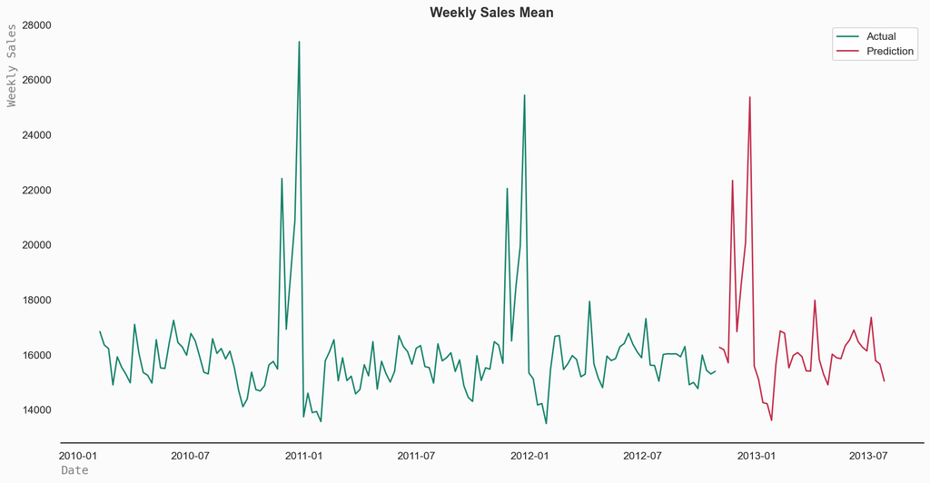

```python
weekly_sales_mean1 = predictData.groupby('Date')['Weekly_Sales_Predict'].mean().reset_index()

fig, axes = plt.subplots(figsize=(16,8), dpi=150, facecolor=background_color)
axes.set_title('Weekly Sales Mean', fontsize=14, fontweight='bold', fontfamily='sans-serif',color='#323232')
sns.lineplot(data=weekly_sales_mean, x="Date", y="Weekly_Sales", color=color2, label='Actual')
sns.lineplot(data=weekly_sales_mean1, x="Date", y="Weekly_Sales_Predict", color=color1, label='Prediction')
axes.set_facecolor(background_color)
axes.tick_params(axis='both', which='both',left=False, bottom=False,labelbottom=True)
axes.set_xlabel('Date', fontfamily='monospace', loc='left', color='gray')
axes.set_ylabel('Weekly Sales', fontfamily='monospace', loc='top',color='gray')

for s in ["top","right", "left"]:
    axes.spines[s].set_visible(False)

plt.show()
```